# Этап №1 индивидуального проекта

Основы информационной безопасности

Бызова М.О.

Российский университет дружбы народов, Москва, Россия

02 февраля 2025

## Цель работы

Приобретение практических навыков по установке операционной системы Linux на виртуальную машину.

## Задание

1. Установить дистрибутив Kali Linux на виртуальную машину VirtualBox.

## Выполнение лабораторной работы

[figure not shown]

Выбор имени и операционной системы

## Выполнение лабораторной работы

Настраиваю основную память и количество выделяемых процессоров, необходимое для работы без помех (рис. 2).

[figure not shown]

Настройка оборудования виртуальной машины

## Выполнение лабораторной работы

Настраиваю размер виртуального жесткого диска, выбираю 40ГБ (рис. 3).

[figure not shown]

Настройка размера виртуального жесткого диска

## Выполнение лабораторной работы

Соглашаюсь с получившимися характеристиками, жму `готово` (рис. 4).

[figure not shown]

Окно создания виртуальной машины

## Выполнение лабораторной работы

Подключаю ранее скачанный образ диска (рис. 5).

[figure not shown]

Подключение образа диска

## Выполнение лабораторной работы

В окне установки Kali выбираю графическую установку (рис. 6).

[figure not shown]

Выбор способа установки

## Выполнение лабораторной работы

Выбираю язык, на котором будет установка (рис. 7).

[figure not shown]

Выбор языка установки

## Выполнение лабораторной работы

В местоположении выбираю Российскую Федерацию (рис. 8).

[figure not shown]

Выбор местоположения

## Выполнение лабораторной работы

Выбираю раскладку клавиатуры (рис. 9).

[figure not shown]

Настройка клавиатуры

## Выполнение лабораторной работы

Выбираю комбинацию горячих клавиш для переключения раскладки клавиатуры (рис. 10).

[figure not shown]

Настройка переключения раслкадки

## Выполнение лабораторной работы

Ввожу имя компьютера (рис. 11).

[figure not shown]

Ввод имени компьютера

## Выполнение лабораторной работы

Ввожу имя домена (рис. 12).

[figure not shown]

Ввод имени домена.

## Выполнение лабораторной работы

Ввожу имя пользователя, у которой будут права суперпользователя (рис. 13).

[figure not shown]

Настройка учетной записи

## Выполнение лабораторной работы

Это же имя по умолчанию предлагается как имя моей учетной записи (рис. 14).

[figure not shown]

Настройка учетной записи

## Выполнение лабораторной работы

Ввожу пароль для созданного пользователя (рис. 15).

[figure not shown]

Настройка пароля

## Выполнение лабораторной работы

Выбираю часовой пояс (рис. 16).

[figure not shown]

Настройка времени

## Выполнение лабораторной работы

Теперь установщик проверяет диски и предлагает различные варианты, в зависимости от настроек. Созданный виртуальный диск чистый, поэтому я выбираю «весь диск» (рис. 17).

[figure not shown]

Разметка дисков

## Выполнение лабораторной работы

Убеждаюсь, что выбран нужный виртуальный диск, продолжаю настройку разметки дисков (рис. 18).

[figure not shown]

Разметка дисков

## Выполнение лабораторной работы

Далее установщик предлагает выбрать схему разметки, ее я оставляю по умолчанию «все файлы в одном разделе» (рис. 19).

[figure not shown]

Разметка дисков

## Выполнение лабораторной работы

После этого этапа надо подтвердить окончание разметки дисков, чтобы изменения были записаны (рис. 20).

[figure not shown]

Разметка дисков

## Выполнение лабораторной работы

Затем установщик дает еще раз просмотреть конфигурацию диска, прежде чем внести необратимые изменения (рис. 21). После этого этапа начнется установка.

[figure not shown]

Разметка дисков

## Выполнение лабораторной работы

Далее я могу выбрать, какие метапакеты (пустые пакеты, которые только описывают зависимости) я хотите установить. Выбор по умолчанию установит стандартную систему Kali Linux, поэтому я не хочу менять выбор (рис. 22).

[figure not shown]

Выбор программного обеспечения

## Выполнение лабораторной работы

Подтверждаю установку системного загрузчика GRUB (Загрузчик операционной системы от проекта GNU программа для управления процессом загрузки), также выбираю виртуальный диск, на который устанавливать GRUB (рис. 23).

[figure not shown]

Установка системного загрузчика

## Выполнение лабораторной работы

Завершаю установку (рис. 24).

[figure not shown]

Завершение установки

## Выполнение лабораторной работы

Проверяю, что в носителях теперь пусто (рис. 25).

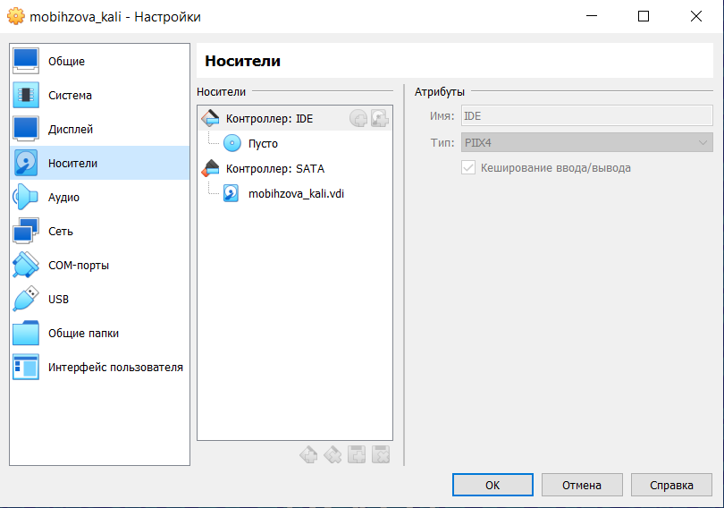

Проверка носителей

## Выполнение лабораторной работы

Вхожу в систему от имени своего пользователя (рис. 26).

[figure not shown]

Вход в систему

## Выполнение лабораторной работы

Вход в систему выполнен успешно, как и ее загрузка (рис. 27).

[figure not shown]

Успешная загрузка системы

## Выводы

Приобрела практические навыки по установке операционной системы Linux на виртуальную машину. Установила дистрибутив Kali LInux на VirtualBox.

## Список литературы. Библиография.

[1] [Официальная документация по устновке Kali Linux на VirtualBox](https://www.kali.org/docs/virtualization/install-virtualbox-guest-vm/)